# Data Analysis Final: R Reference Guide

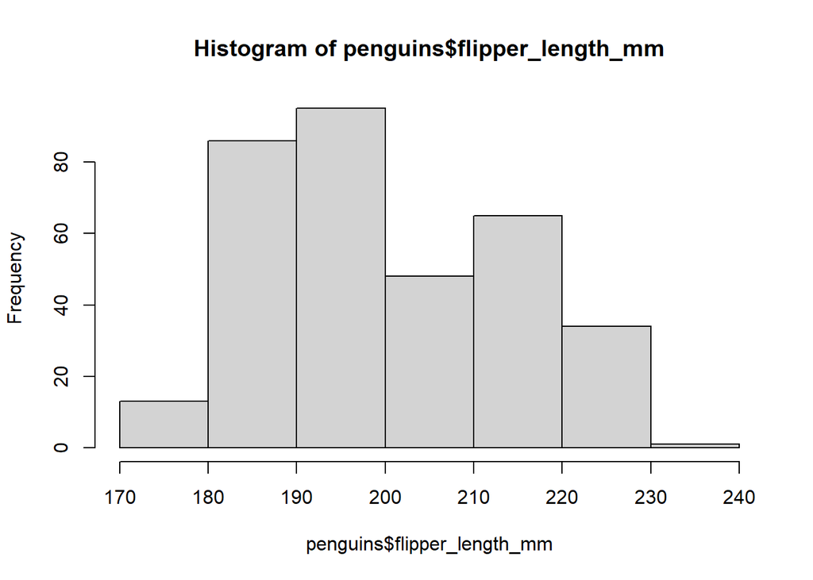

```r
hist(penguins$flipper_length_mm, breaks = c(170, 180, 190, 200, 210, 220, 230, 240)) #Now, breaks = is not a suggestion, it is a vector of start/end points that R must use, but this is a little long winded if we had a large range
```

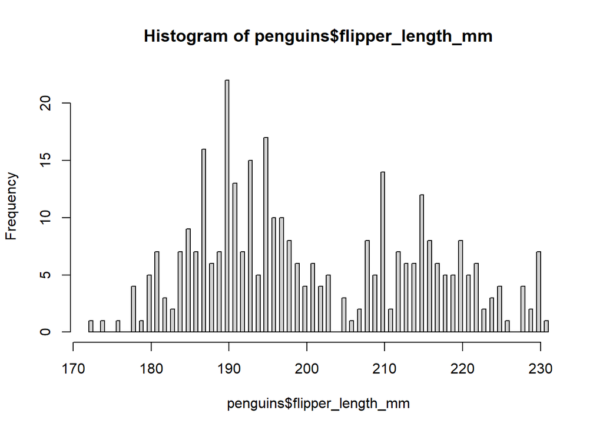

```r
FUN1 <- function(x1){
  mini <- min(x1, na.rm = TRUE)
  maxi <- max(x1, na.rm = TRUE)
  rang <- (mini + maxi)/2
  return(rang)
  }


hist(penguins$flipper_length_mm, breaks = FUN1(penguins$flipper_length_mm)) # Thist breaks uses a function (FUN1) that is just for demonstration
```

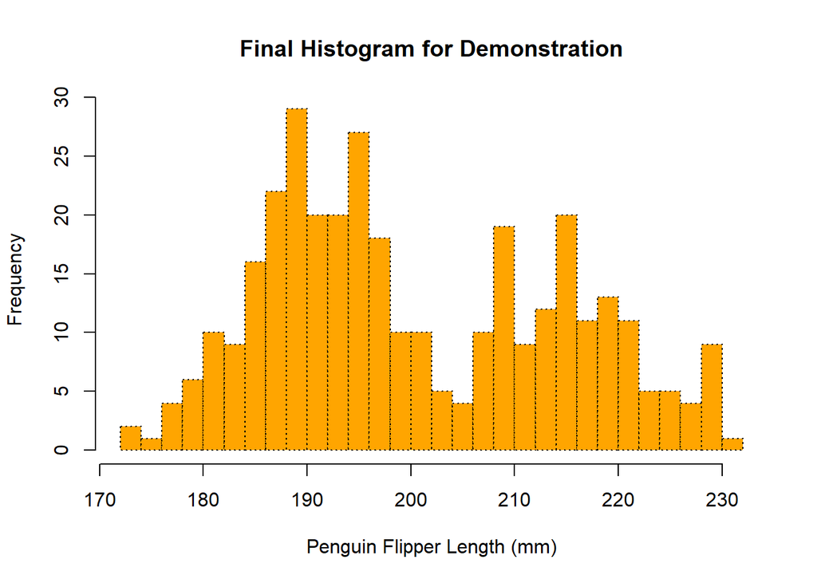

```r
hist(penguins$flipper_length_mm, breaks = 26, main = "Final Histogram for Demonstration", xlab = "Penguin Flipper Length (mm)", col = "orange", lty = 3) #can use many of the same formatting arguments as we saw under plot(). lty = line type - again there are 20 specified by integers.
```

### boxplot() (Box Plots)

The boxplot() function allows you to visualize continuous response data with a categorical predictor.

Here is a simple boxplot that graphically shows the summary information for one continuous response variable:

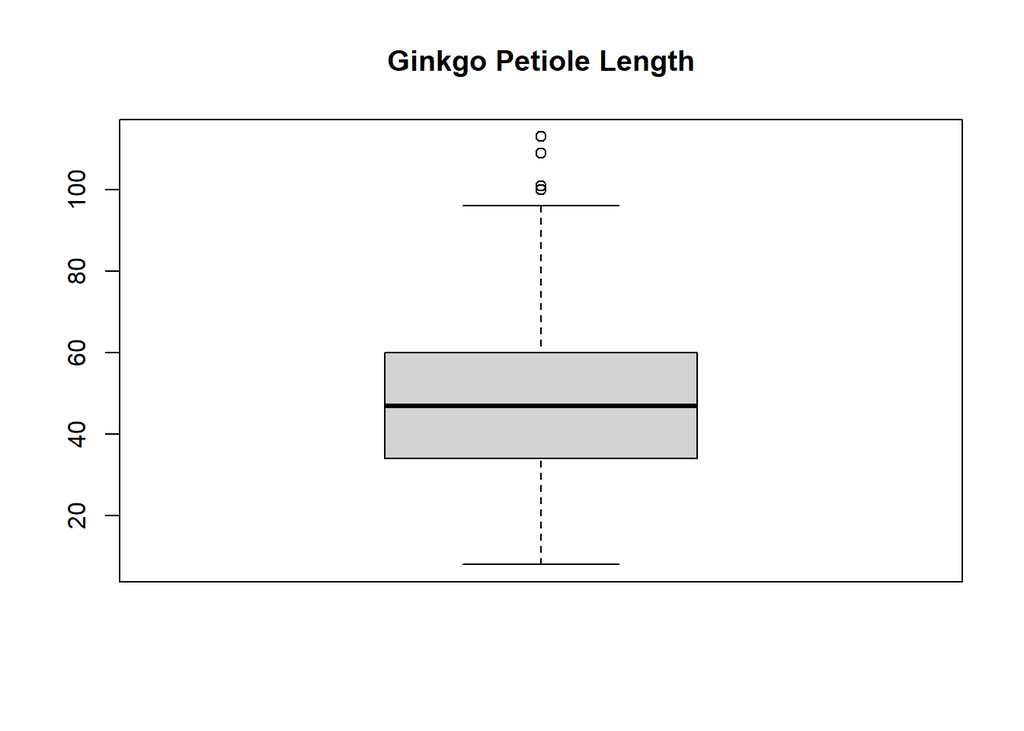

```r
boxplot(ginkgo$petiole_length, main = "Ginkgo Petiole Length")
```

The continuous response data, such as Ginkgo Petiole Length, can be conditioned on a categorical response data to visually assess if the groupings are similar.

Conditional boxplot:

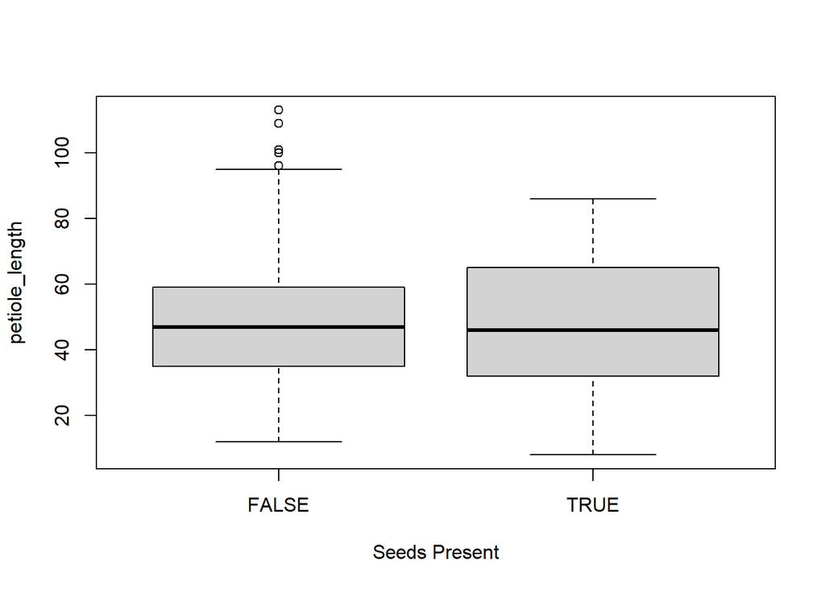

```r
boxplot(petiole_length ~ seeds_present, data = ginkgo, xlab = "Seeds Present")
```

### par()

The par() function controls graphical parameters. It can be used to adjust margins in the figure and to arrange multiple graphs into one figure by using par(mfrow = )

Here’s the example:

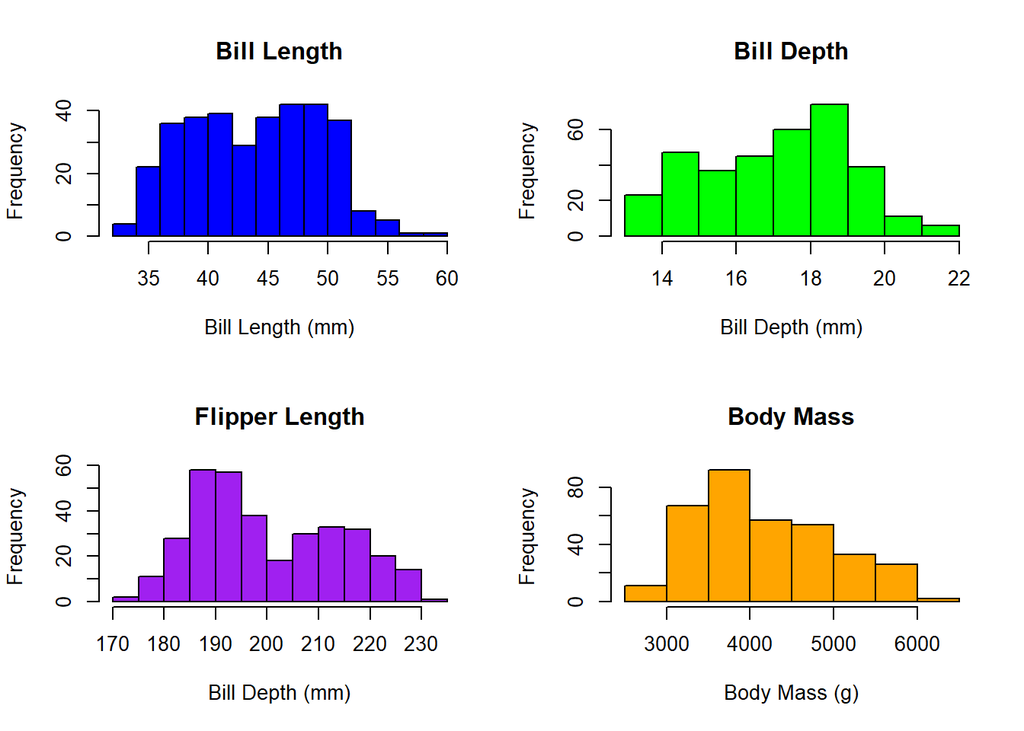

```r
par(mfrow = c(2,2))
hist(penguins$bill_length_mm, main = "Bill Length", xlab = "Bill Length (mm)", col = "blue")
hist(penguins$bill_depth_mm, main = "Bill Depth", xlab = "Bill Depth (mm)", col = "green")
hist(penguins$flipper_length_mm, main = "Flipper Length", xlab = "Bill Depth (mm)", col = "purple")
hist(penguins$body_mass_g, main = "Body Mass", xlab = "Body Mass (g)", col = "orange")
```

## Distribution Functions

### dnorm()

The dnorm() function is the probability density function for normal continuous distributions.It returns the probability of a given value along a normal distribution. In other words, it gives the height of the probability distribution for a given x value.

The arguments include:

- x - the value(s) you want to know the probability of
- mean - the distribution mean
- sd - the distribution standard deviation
- log - defaults to FALSE, can be overridden to TRUE if you have a logarithmic distribution

```r
dnorm(2, mean = 5, sd = 2) #For a normal distribution with a mean of 5 and a standard deviation of 2, there is a 6.5% chance of observing the value 2
```

```
## [1] 0.0647588
```

### pnorm()

The pnorm() function is the cumulative density function for the normal continuous distribution. It returns the probability of observing any value less than or equal to a given value. In other words, it gives the total area under the curve from x=0 to x=given argument.

The arguments are the same as for dnorm() with the addition of:

- lower.tail = TRUE - which is the default and returns the cumulative probability of less than the given number, or
- lower.tail = FALSE - which returns the inverse of TRUE (1-lower.tail = TRUE)

```r
pnorm(2, mean = 5, sd = 2) #6.7% chance of observing a value of 2 or less (remember dbinom provided only the chance of observing a value of 2)
```

```
## [1] 0.0668072
```

```r
pnorm(2, mean = 5, sd = 2, lower.tail = FALSE) #93.3% chance of observing a value greater than 2 (the inverse of above)
```

```
## [1] 0.9331928
```

### qnorm()

The qnorm() function is the quantile density function for the normal continuous distribution. It returns the value from the distribution at a given quantile.

The arguments are the same as the dnorm except for the entered value, which represents a quantile as a decimal value.

```r
qnorm(0.90, mean = 5, sd = 2) #At the 90% percentile, we would observe a value of 7.5
```

```
## [1] 7.563103
```

### dbinom()

The dbinom() function is the probability mass function for the binomial discrete distribution with two outcomes. This function provides the probability density distribution for any given number of “successes” in the provided distribution.

The arguments are:

- x - the number of successes you’re calculating
- size - number of trials
- prob - probability of success (must be the same for every trial)
- log = FALSE - default, can be over-ridden to TRUE

```r
dbinom(3, 10, 0.5) #11.7% chance of getting 3 successes in 10 trials with a probability of success of 50%
```

```
## [1] 0.1171875
```

### pbinom()

The pbinom() function is the cumulative mass function for the binomial discrete distribution. This function provides the probability of observing a given number or fewer successes.

The arguments are the same as the dbinom function, except:

- q - probability, instead of x. Similar to the pnorm,
- lower.tail and log can be set to TRUE or FALSE.

```r
pbinom(3, 10, 0.5) #17% chance of getting 3 or fewer success in 10 trials with a probability of success of 50%.
```

```
## [1] 0.171875
```

### qbinom()

The qbinom() function is the quantile function for the binomial discrete distribution. This function provides the number of successes that would be observed within a given percentile of the distribution.

The arguements are the same as the dbinom() except for the entered value, which represents a quantile as a decimal value.

```r
qbinom(.17, 10, 0.5) # At the 17th percentile, with 10 trials and a success rate of 50%, you would observe 3 successes.
```

```
## [1] 3
```